# Proyecto analisis exploratorio y clustering

Andres Quinto, Mirka Monzon, Oscar De Leon, Oscar Ramos, Diego Crespo

26/03/2022

```r
library(haven)
library(foreign)

datos2015 <- read_sav("./SAVS/2015M.sav")

#NO FUE NECESARIO REALIZAR CAMBIOS
```

```r
library(haven)
library(foreign)

datosNacim2015 <- read_sav("./SAVS/2015N.sav")

#NO FUE NECESARIO REALIZAR CAMBIOS
```

```r
library(haven)
library(foreign)

datosNacim2016 <- read_sav("./SAVS/2016N.sav")

#NO FUE NECESARIO REALIZAR CAMBIOS
```

```r
library(haven)
library(foreign)

datos2016 <- read_sav("./SAVS/2016M.sav")

#NO FUE NECESARIO REALIZAR CAMBIOS
```

```r
library(haven)
library(foreign)

datosNacim2019 <- read_sav("./2019N.sav")

#NO FUE NECESARIO REALIZAR CAMBIOS
```

```r
library(haven)
library(foreign)

datos2015 <- read_sav("./SAVS/2015M.sav")

#NO FUE NECESARIO REALIZAR CAMBIOS
```

```r
library(haven)
library(foreign)

datosNacim2015 <- read_sav("./SAVS/2015N.sav")

#NO FUE NECESARIO REALIZAR CAMBIOS
```

```r
library(haven)
library(foreign)

datosNacim2016 <- read_sav("./SAVS/2016N.sav")

#NO FUE NECESARIO REALIZAR CAMBIOS
```

```r
library(haven)
library(foreign)

datos2016 <- read_sav("./SAVS/2016M.sav")

#NO FUE NECESARIO REALIZAR CAMBIOS
```

```r
library(haven)
library(foreign)

datosNacim2019 <- read_sav("./2019N.sav")

#NO FUE NECESARIO REALIZAR CAMBIOS
```

```r
#install.packages("tidyverse")
library(tidyverse)
library(haven)
library(foreign)
#Lectura y conversion de los .SAV

# Comentados los savs que ya fueron convertidos en .csv
# write.csv(X2011, 'X2011.csv')
# write.csv(X2012, 'X2012.csv')
# write.csv(X2013, 'X2013.csv')
# write.csv(base1, 'base1.csv')
# write.csv(X2016, 'X2016.csv')
# write.csv(matri2014, 'matri2014 .csv')
# write.csv(matri2015 , 'matri2015 .csv')
# write.csv(matri2016 , 'matri2016 .csv')
#

datos2011 <- read_sav("./SAVS/20111.sav")
datos2012 <- read_sav("./SAVS/20122.sav")
datosNacim2011 <- read_sav("./SAVS/2011N.sav")
datosNacim2012 <- read_sav("./SAVS/nacim2012.sav")
datos2019 <- read_sav("./SAVS/2019M.sav")

#---------------------Modificaciones 2011----------------------
#Crear columnas en dataset 2011 NUNUHO, NUNUMU
NUNUHO <- rnorm(nrow(datos2011))
datos2011 <- cbind(datos2011,NUNUHO)
datos2011$NUNUHO <- "None"
NUNUMU <- rnorm(nrow(datos2011))
datos2011 <- cbind(datos2011, NUNUMU)
datos2011$NUNUMU <- "None"
#Poner todas en uppercase 2011
cnames <- colnames(datos2011)
mayu2011 = c()
for (i in 1:length(cnames)){
  mayu2011[i] <- toupper(cnames[i])
}
colnames(datos2011)<-mayu2011
#cambiar AREAG por AREAGOCU, OCUHOM, OCUMUJ, PUEHOM, PUEMUJ
cnames <- colnames(datos2011)
nombresN = c()
for(i in 1:length(cnames)){
  if(cnames[i] == "AREAG"){
    nombresN[i] <- "AREAGOCU"
  }
  else if(cnames[i] == "OCUHOM"){
    nombresN[i] <- "CIUOHOM"
  }
  else if(cnames[i] == "OCUMUJ"){
    nombresN[i] <- "CIUOMUJ"
  }
  else if(cnames[i] == "GETHOM"){
    nombresN[i] <- "PUEHOM"
  }
  else if(cnames[i] == "GETMUJ"){
    nombresN[i] <- "PUEMUJ"
  }
  else{
    nombresN[i] <- cnames[i]
  }
}
colnames(datos2011) <- nombresN

#-------------------------Modificaciones 2012------------------------

#Crear columnas en dataset 2012 AÑOOCU, NUNUHO, NUNUMU
AÑOOCU <- rnorm(nrow(datos2012))
datos2012 <- cbind(datos2012, AÑOOCU)
datos2012$AÑOOCU <- "None"
NUNUHO <- rnorm(nrow(datos2012))
datos2012 <- cbind(datos2012,NUNUHO)
datos2012$NUNUHO <- "None"
NUNUMU <- rnorm(nrow(datos2012))
datos2012 <- cbind(datos2012, NUNUMU)
datos2012$NUNUMU <- "NA"
#View(datos2012)
#cambiar AREAG por AREAGOCU, OCUHOM, OCUMUJ, PUEHOM, PUEMUJ
cnames <- colnames(datos2012)
nombresN = c()
for(i in 1:length(cnames)){
  if(cnames[i] == "AREAG"){
    nombresN[i] <- "AREAGOCU"
  }
  else if(cnames[i] == "OCUHOM"){
    nombresN[i] <- "CIUOHOM"
  }
  else if(cnames[i] == "OCUMUJ"){
    nombresN[i] <- "CIUOMUJ"
  }
  else if(cnames[i] == "GETHOM"){
    nombresN[i] <- "PUEHOM"
  }
  else if(cnames[i] == "GETMUJ"){
    nombresN[i] <- "PUEMUJ"
  }
  else{
    nombresN[i] <- cnames[i]
  }
}
colnames(datos2012) <- nombresN
#datos2012$AÑOOCU <- ifelse(datos2012$AÑOOCU == 'None', 2012, datos2012$AÑOOCU)

#-------------------------Modificaciones 2019------------------------
#Agregar columna areagocu
#Poner todas en uppercase 2019
AREAGOCU <- rnorm(nrow(datos2019))
datos2019 <- cbind(datos2019, AREAGOCU)
datos2019$AREAGOCU <- "None"

#-------------------------Modificaciones Nacimientos 2019------------------------
cnames <- colnames(datosNacim2019)
mayu2011 = c()
for (i in 1:length(cnames)){
  mayu2011[i] <- toupper(cnames[i])
}
colnames(datosNacim2019)<-mayu2011
#CAMBIOS DE BASE NACIMIENTOS 2011 PARA QUE SEA SIMILAR A 2019
#Poner todas en uppercase 2011
cnames <- colnames(datosNacim2011)
mayu2011 = c()
for (i in 1:length(cnames)){
  mayu2011[i] <- toupper(cnames[i])
}
colnames(datosNacim2011)<-mayu2011

#Cambiar MUPNAP a MUNPNAP
cnames <- colnames(datosNacim2011)
nombresN = c()
for(i in 1:length(cnames)){
  if(cnames[i] == "MUPNAP"){
    nombresN[i] <- "MUNPNAP"
  }
}
#AGREGAR LAS COLUMNAS FALTANTES Y LLENARLAS DE NONE
TIPOINS <- rnorm(nrow(datosNacim2011))
datosNacim2011 <- cbind(datosNacim2011, TIPOINS)
datosNacim2011$TIPOINS <- "None"

VIAPAR <- rnorm(nrow(datosNacim2011))
datosNacim2011 <- cbind(datosNacim2011, VIAPAR)
datosNacim2011$VIAPAR <- "None"

PAISREP <- rnorm(nrow(datosNacim2011))
datosNacim2011 <- cbind(datosNacim2011, PAISREP)
datosNacim2011$PAISREP <- "None"

PUEBLOPP <- rnorm(nrow(datosNacim2011))
datosNacim2011 <- cbind(datosNacim2011, PUEBLOPP)
datosNacim2011$PUEBLOPP <- "None"

PAISNACP <- rnorm(nrow(datosNacim2011))
datosNacim2011 <- cbind(datosNacim2011, PAISNACP)
datosNacim2011$PAISNACP <- "None"

PAISREM <- rnorm(nrow(datosNacim2011))
datosNacim2011 <- cbind(datosNacim2011, PAISREM)
datosNacim2011$PAISREM <- "None"

PUEBLOPM <- rnorm(nrow(datosNacim2011))
datosNacim2011 <- cbind(datosNacim2011, PUEBLOPM)
datosNacim2011$PUEBLOPM <- "None"

PAISNACM <- rnorm(nrow(datosNacim2011))
datosNacim2011 <- cbind(datosNacim2011, PAISNACM)
datosNacim2011$PAISNACM <- "None"
#ELIMINAMOS LAS COLUMNAS EXTRAS

datosNacim2011 = datosNacim2011[,!(names(datosNacim2011) %in% c("AREAG","GRETNP", "NACIOP","GRUPETMA","NACIOM"))]

#CAMBIOS DE BASE NACIMIENTOS 2012 PARA QUE SEA SIMILAR A 2019
#Poner todas en uppercase 2012
cnames <- colnames(datosNacim2012)
mayu2011 = c()
for (i in 1:length(cnames)){
  mayu2011[i] <- toupper(cnames[i])
}
colnames(datosNacim2012)<-mayu2011

#Cambiar MUPNAP a MUNPNAP
cnames <- colnames(datosNacim2012)
nombresN = c()
for(i in 1:length(cnames)){
  if(cnames[i] == "MUPNAP"){
    nombresN[i] <- "MUNPNAP"
  }
}
#AGREGAR LAS COLUMNAS FALTANTES Y LLENARLAS DE NONE
TIPOINS <- rnorm(nrow(datosNacim2012))
datosNacim2012 <- cbind(datosNacim2012, TIPOINS)
datosNacim2012$TIPOINS <- "None"

VIAPAR <- rnorm(nrow(datosNacim2012))
datosNacim2012 <- cbind(datosNacim2012, VIAPAR)
datosNacim2012$VIAPAR <- "None"

PAISREP <- rnorm(nrow(datosNacim2012))
datosNacim2012 <- cbind(datosNacim2012, PAISREP)
datosNacim2012$PAISREP <- "None"

PUEBLOPP <- rnorm(nrow(datosNacim2012))
datosNacim2012 <- cbind(datosNacim2012, PUEBLOPP)
datosNacim2012$PUEBLOPP <- "None"

PAISNACP <- rnorm(nrow(datosNacim2012))
datosNacim2012 <- cbind(datosNacim2012, PAISNACP)
datosNacim2012$PAISNACP <- "None"

PAISREM <- rnorm(nrow(datosNacim2012))
datosNacim2012 <- cbind(datosNacim2012, PAISREM)
datosNacim2012$PAISREM <- "None"

PUEBLOPM <- rnorm(nrow(datosNacim2012))
datosNacim2012 <- cbind(datosNacim2012, PUEBLOPM)
datosNacim2012$PUEBLOPM <- "None"

PAISNACM <- rnorm(nrow(datosNacim2012))
datosNacim2012 <- cbind(datosNacim2012, PAISNACM)
datosNacim2012$PAISNACM <- "None"
#ELIMINAMOS LAS COLUMNAS EXTRAS

datosNacim2012 = datosNacim2012[,!(names(datosNacim2012) %in% c("AREAG","GRETNP", "NACIOP","GRUPETMA","NACIOM"))]
```

```r
library(haven)
library(foreign)

datos2013 <- read_sav("./SAVS/2013M.sav")

#-------------------------Modificaciones 2013 matrimonios------------------------
#columnas a crear para año 2013: NUNUHO, NUNUMU
#no hay columnas para cambiar

#NUNUHO
NUNUHO <- rnorm(nrow(datos2013))
datos2013 <- cbind(datos2013,NUNUHO)
datos2013$NUNUHO <- "None"

#NUNUMU
NUNUMU <- rnorm(nrow(datos2013))
datos2013 <- cbind(datos2013, NUNUMU)
datos2013$NUNUMU <- "NA"
```

```r
library(haven)
library(foreign)

datos2014 <- read_sav("./SAVS/2014M.sav")

#-------------------------Modificaciones 2014 matrimonios------------------------
#columnas a crear para año 2014: NUNUHO, NUNUMU
#no hay comunas para cambiar

#NUNUHO
NUNUHO <- rnorm(nrow(datos2014))
datos2014 <- cbind(datos2014,NUNUHO)
datos2014$NUNUHO <- "None"

#NUNUMU
NUNUMU <- rnorm(nrow(datos2014))
datos2014 <- cbind(datos2014, NUNUMU)
datos2014$NUNUMU <- "NA"

#Agregar columna anoocu
AÑOOCU <- rnorm(nrow(datos2014))
datos2014 <- cbind(datos2014, AÑOOCU)
datos2014$AÑOOCU <- "None"
```

```r
library(haven)
library(foreign)

datosN2013 <- read_sav("./SAVS/2013N.sav")

#-------------------------Modificaciones 2013 nacimientos------------------------
#columnas a crear para año 2013: TIPOINS, AÑOOCU, VIAPAR
#columnas a cambiar: CIUPAD - OCUPAP / CIUMAD - OCUPAM
#columnas a borrar: NACIOP, ESCOLAP, NACIOM

#TIPOINS
TIPOINS <- rnorm(nrow(datosN2013))
datosN2013 <- cbind(datosN2013,TIPOINS)
datosN2013$TIPOINS <- "None"

#AÑOOCU
AÑOOCU <- rnorm(nrow(datosN2013))
datosN2013 <- cbind(datosN2013,AÑOOCU)
datosN2013$AÑOOCU <- "None"

#VIAPAR
VIAPAR <- rnorm(nrow(datosN2013))
datosN2013 <- cbind(datosN2013,VIAPAR)
datosN2013$VIAPAR <- "None"

#cambio de nombre de columnas
cnames <- colnames(datosN2013)
nombresN = c()
for(i in 1:length(cnames)){
  if(cnames[i] == "CIUPAD"){
    nombresN[i] <- "OCUPAP"
  }
  else if(cnames[i] == "CIUMAD"){
    nombresN[i] <- "OCUPAM"
  }
  else{
    nombresN[i] <- cnames[i]
  }
}
colnames(datosN2013) <- nombresN

#drop NACIOP
datosN2013$NACIOP <- NULL

#drop ESCOLAP
datosN2013$ESCOLAP <- NULL

#drop NACIOM
datosN2013$NACIOM <- NULL
```

```r
library(haven)
library(foreign)

datosN2014 <- read_sav("./SAVS/2014N.sav")

#-------------------------Modificaciones 2014 nacimientos------------------------
#columnas a crear para año 2013: TIPOINS, AÑOOCU, VIAPAR, OCUPAP
#columnas a cambiar: NA
#columnas a borrar: CIUMAD

#TIPOINS
TIPOINS <- rnorm(nrow(datosN2014))
datosN2014 <- cbind(datosN2014,TIPOINS)
datosN2014$TIPOINS <- "None"

#AÑOOCU
AÑOOCU <- rnorm(nrow(datosN2014))
datosN2014 <- cbind(datosN2014,AÑOOCU)
datosN2014$AÑOOCU <- "None"

#VIAPAR
VIAPAR <- rnorm(nrow(datosN2014))
datosN2014 <- cbind(datosN2014,VIAPAR)
datosN2014$VIAPAR <- "None"

#OCUPAP
OCUPAP <- rnorm(nrow(datosN2014))
datosN2014 <- cbind(datosN2014,OCUPAP)
datosN2014$OCUPAP <- "None"

#drop CIUMAD
datosN2014$CIUMAD <- NULL
```

```r
library(haven)
library(foreign)

datos2013 <- read_sav("./SAVS/2013M.sav")

#-------------------------Modificaciones 2013------------------------
#columnas a crear para año 2013: NUNUHO, NUNUMU
#no hay columnas para cambiar
#columnas por borrar: x

#NUNUHO
NUNUHO <- rnorm(nrow(datos2013))
datos2013 <- cbind(datos2013,NUNUHO)
datos2013$NUNUHO <- "None"

#NUNUMU
NUNUMU <- rnorm(nrow(datos2013))
datos2013 <- cbind(datos2013, NUNUMU)
datos2013$NUNUMU <- "NA"

#Agregar columna anoocu
AÑOOCU <- rnorm(nrow(datos2013))
datos2013 <- cbind(datos2013, AÑOOCU)
datos2013$AÑOOCU <- "None"
```

```r
#UNIMOS LAS BASES DE MATRIMONIOS DEL 2011 AL 2016
#---------- Ya con todas las bases con las mismas columnas (cant columnas y nombres) podemos unirlas

#install.packages("sf")
library(dplyr)
library(sf)
#------------------------Unión de las bases-------------------------
datos2011 <- datos2011 %>%
  mutate_if(is.labelled,list(as_factor))
datos2012 <- datos2012 %>%
  mutate_if(is.labelled,list(as_factor))
datos2013 <- datos2013 %>%
  mutate_if(is.labelled,list(as_factor))
datos2014 <- datos2014 %>%
  mutate_if(is.labelled,list(as_factor))
datos2015 <- datos2015 %>%
  mutate_if(is.labelled,list(as_factor))
datos2016 <- datos2016 %>%
  mutate_if(is.labelled,list(as_factor))

l = list(datos2011,datos2012,datos2013,datos2014,datos2015,datos2016)
datosMatrimonio <- do.call("rbind",l)
datosMatrimonio$EDADHOM <- as.numeric(factor(datosMatrimonio$EDADHOM))
datosMatrimonio$EDADMUJ <- as.numeric(factor(datosMatrimonio$EDADMUJ))

datosMatrimonio$ESCHOM <- ifelse(datosMatrimonio$ESCHOM == "DIversificado","Diversificado",datosMatrimonio$ESCHOM)
datosMatrimonio$ESCHOM <- ifelse(datosMatrimonio$ESCHOM == "Post Grado","Universitario",datosMatrimonio$ESCHOM)
datosMatrimonio$ESCHOM <- ifelse(datosMatrimonio$ESCHOM == "Postgrado","Universitario",datosMatrimonio$ESCHOM)
datosMatrimonio$ESCMUJ <- ifelse(datosMatrimonio$ESCMUJ == "DIversificado","Diversificado",datosMatrimonio$ESCMUJ)
datosMatrimonio$ESCMUJ <- ifelse(datosMatrimonio$ESCMUJ == "Post Grado","Universitario",datosMatrimonio$ESCMUJ)
datosMatrimonio$ESCMUJ <- ifelse(datosMatrimonio$ESCMUJ == "Postgrado","Universitario",datosMatrimonio$ESCMUJ)


datosMatrimonio$DEPOCU <- levels(datosMatrimonio$DEPOCU)[datosMatrimonio$DEPOCU]
datosMatrimonio$DEPOCU <- ifelse(datosMatrimonio$DEPOCU == "Totonicapán","Totonicapan",datosMatrimonio$DEPOCU)
datosMatrimonio$DEPOCU <- ifelse(datosMatrimonio$DEPOCU == "Petén","Peten",datosMatrimonio$DEPOCU)
datosMatrimonio$DEPOCU <- factor(datosMatrimonio$DEPOCU)


datosMatrimonio$PUEHOM <- levels(datosMatrimonio$PUEHOM)[datosMatrimonio$PUEHOM]
datosMatrimonio$PUEMUJ <- levels(datosMatrimonio$PUEMUJ)[datosMatrimonio$PUEMUJ]

datosMatrimonio$PUEHOM <- ifelse(datosMatrimonio$PUEHOM == "No Indigena", "No indigena",datosMatrimonio$PUEHOM)
datosMatrimonio$PUEMUJ <- ifelse(datosMatrimonio$PUEMUJ == "No Indigena", "No indigena",datosMatrimonio$PUEMUJ)


datosMatrimonio$PUEHOM <- factor(datosMatrimonio$PUEHOM)
datosMatrimonio$PUEMUJ <- factor(datosMatrimonio$PUEMUJ)
```

## Informe de análisis exploratorio

A continuación la explicación de qué representa cada una de las variables: DEPREG: departamento de registro MUPREG: municipio de registro MESREG: mes de registro AÑOREG: año de registro CLAUNI: clase de unión EDADHOM: edad del hombre EDADMUJ: edad de la mujer PUEHOM: etnia del hombre PUEMUJ: etnia de la mujer NACHOM: nacionalidad del hombre NACMUJ: nacionalidad de la mujer CIUOHOM: ocupación del hombre CIUOMUJ: ocupación de la mujer NUNUHO: número de nupcias del hombre NUNUMU: número de nupcias de la mujer DEPOCU: departamento de ocurrencia MUPOCU: municipio de ocurrencia MESOCU: mes de ocurrencia AÑOOCU: año de ocurrencia AREAGOCU: área geográfica de ocurrencia ESCHOM: escolaridad del hombre ESCMUJ: escolaridad de la mujer

En el siguiente cuadro se muestra el tipo de dato de cada una de las variables mencionadas anteriormente:

```
## 'data.frame':    471575 obs. of  23 variables:
##  $ DEPREG  : Factor w/ 22 levels "Guatemala","El Progreso",..: 1 1 8 1 1 6 5 1 1 10 ...
##  $ MUPREG  : Factor w/ 337 levels "Guatemala","Santa Catarina Pinula",..: 1 8 104 1 3 78 64 2 2 136 ...
##  $ MESREG  : Factor w/ 12 levels "Enero","Febrero",..: 12 1 12 11 11 1 7 3 7 10 ...
##  $ AÑOREG  : num  2011 2012 2011 2011 2011 ...
##   ..- attr(*, "label")= chr "Año de registro"
##   ..- attr(*, "format.spss")= chr "F4.0"
##   ..- attr(*, "display_width")= int 6
##  $ CLAUNI  : Factor w/ 4 levels "Comunidad absoluta",..: 3 2 3 2 3 3 4 3 3 4 ...
##  $ EDADHOM : num  15 17 9 46 19 15 15 17 26 20 ...
##  $ EDADMUJ : num  23 22 8 44 15 16 15 41 21 14 ...
##  $ PUEHOM  : Factor w/ 8 levels "Garífuna","Ignorado",..: 2 2 3 2 6 6 6 6 6 2 ...
##  $ PUEMUJ  : Factor w/ 8 levels "Garífuna","Ignorado",..: 6 2 2 2 6 6 6 6 6 6 ...
##  $ NACHOM  : Factor w/ 101 levels "Turquia","Corea",..: 10 21 21 21 21 21 21 23 5 21 ...
##  $ NACMUJ  : Factor w/ 76 levels "Turquia","Argentina",..: 21 21 21 21 21 21 21 21 21 21 ...
```

[output cut: 17 more lines]

Las variables más interesantes para el porpósito de la investigación son las que proporcionan información de la fecha del matrimonio. Otras con gran potencial son las edades de los cónyuges, ya que con ellas podemos analizar cual es la tendencia de matrimonios de menores, diferencias de edades etc.

## Análisis de variables cuantitativas

### Registros de matrimonio

#### Prueba de normalidad para registros de matrimonios:

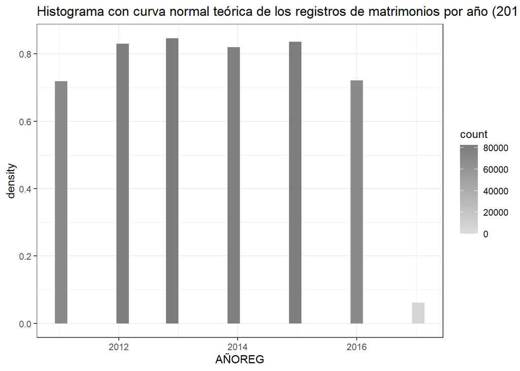

Como es de esperarse, no es posible observar que exista una relación en el histograma de registros de matrimonios con las reformas planteadas para la prohibición de matrimonios con menores de edad, ya que parece que la cantidad de matrimonios ha sido bastante constante durante los años. Según el histograma mostrado, la cantidad de matrimonios por año no sigue una distribución normal.

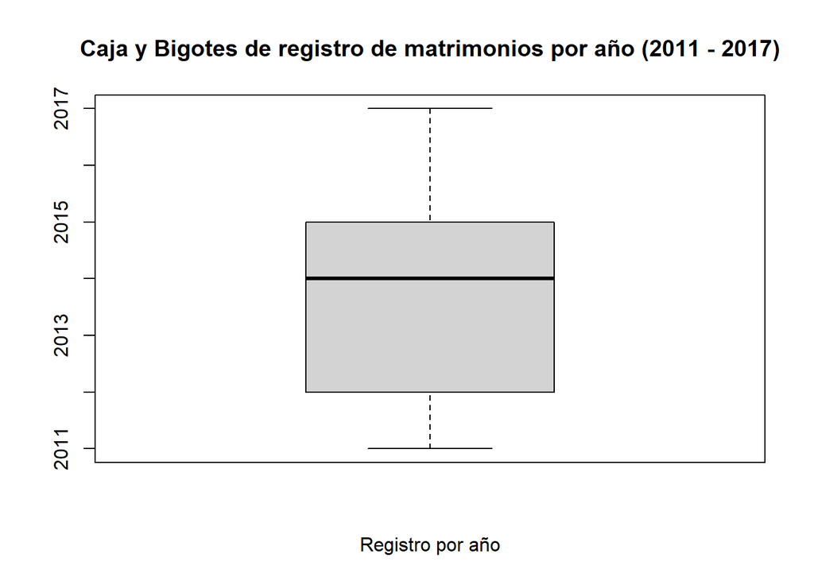

### Diagrama de qqnormal

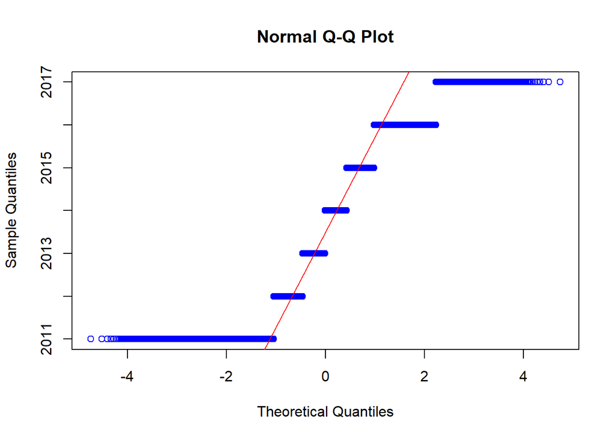

Aunque en el diagrama qqnormal parece que se sigue una distribución normal al encontrarse muchos de los datos alineados, hay bastantes datos que se encuentran fuera de la linea de tendencia, por lo que no se cumple con normalidad en la cantidad de matrimonios por año.

En conclusión, la cantidad de matrimonios por año no sigue una distribución normal.

## Registros de Edad hombre

### Prueba de normalidad para la edad del hombre:

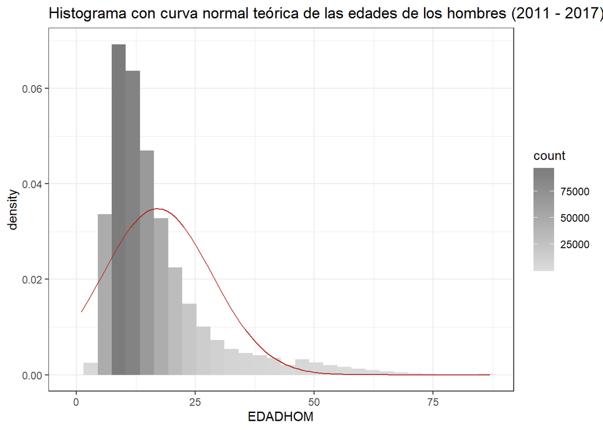

En este histograma se puede observar que los datos tienen relativamente forma de campana, sin embargo, es evidente que estos tienen un sesgo hacia la izquierda, esto quiere decir que usualmente la edad entre los hombres en un matrimonio se encuentra debajo de los 30. Sin embargo, es importante mencionar que como dato interesante se puede observar que hay casos de matrimonios en hombres de más de 75 años. Debido al sesgo, la edad de los hombres en matrimonios no sigue una distribución normal.

### Diagrama de caja y bigotes

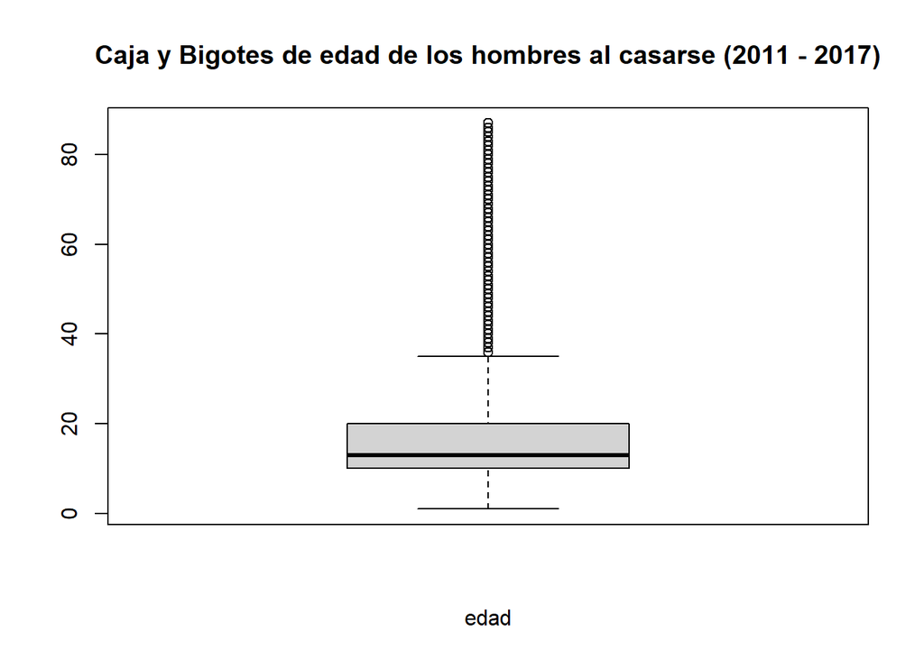

Se evidencia la gran cantidad de datos atípicos en el diagrama, se encuentran muy dispersos arriba de la media y del extremo superior que se encuentra al rededor de los 30 años. Esto quiere decir que la edad de los hombres en el matrimonio no sigue una distribución normal.

### Diagrama qqnormal

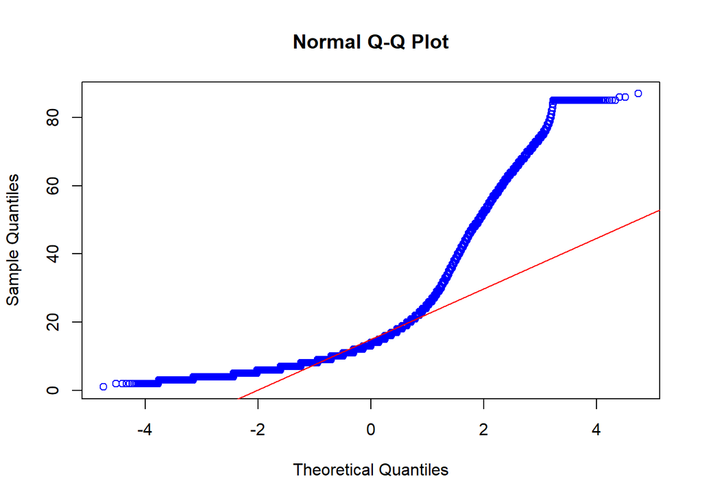

Como puede observarse, es muy notable en el diagrama qqnormal que los datos no siguen una distribución acorde a la linea de tendencia, esto quiere decir que la edad del hombre en el matrimonio no sigue una distribución normal.

En conclusión, la edad de los hombres en el matrimonio no sigue una distribución normal.

## Registros de edad de mujeres

### Prueba de normalidad para la edad de la mujer:

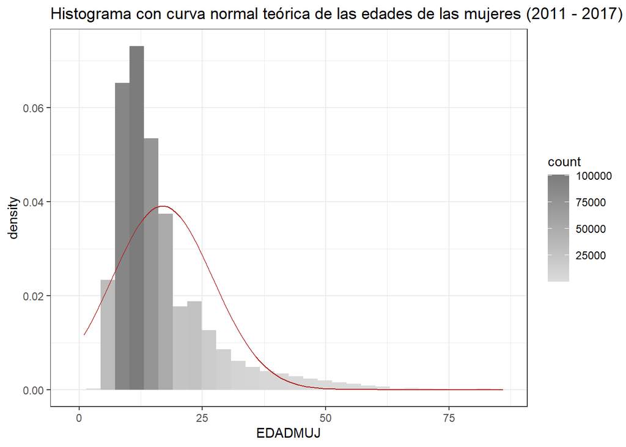

De la misma manera que en el histograma de hombres, hay una forma relativa de campana, sin embargo se nota un gran sesgo a la izquierda que demuestra que la edad de mujeres en el matrimonio suele ser debajo de los 25, aunque también se cuentan con algunos datos arriba de los 75 años. Debido al sesgo, la edad de mujeres en el matrimonio no sigue una distribución normal.

### Diagrama de caja y bigotes

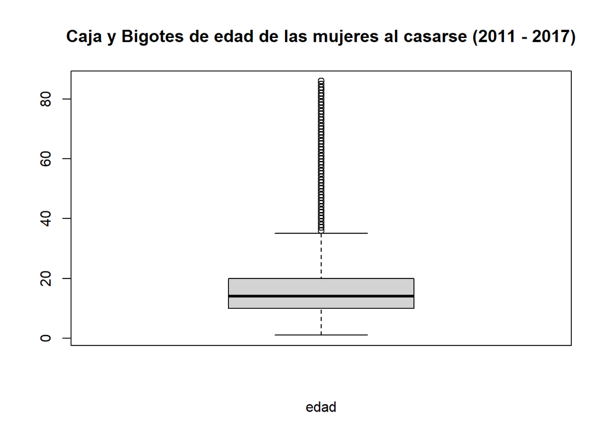

En este diagrama de caja y bigotes es posible ver una gran cantidad de datos atípicos arriba del extremo superior que se encuentra al rededor de los 30 años, muy similar al diagrama de la edad de los hombres, por lo que de la misma manera no se cuenta con normalidad en la edad de las mujeres en el matrimonio.

### Diagrama qqnormal

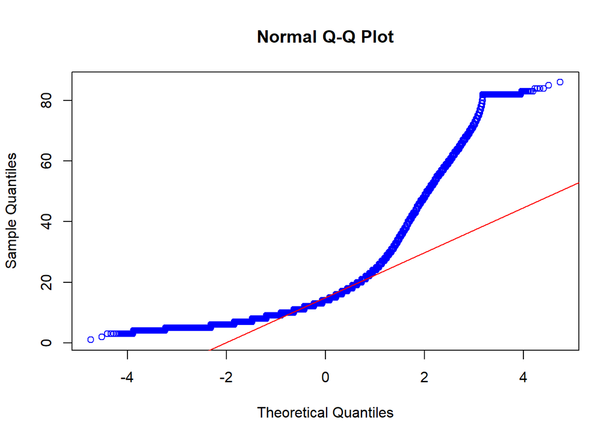

Como puede observarse, los valores en este diagrama evidentemente no siguen con una distribución normal ya que no esán sobre la linea de tendencia, por lo que la edad de las mujeres en el matrimonio no sigue una distribución normal.

En conclusión, la edad de las mujeres en el matrimonio no sigue una distribución normal.

### Tabla de frecuencias para el departamento de ocurrencia y representación gráfica

```
##
##   Alta Verapaz   Baja Verapaz  Chimaltenango     Chiquimula    El Progreso
##          31116           9024          23440          10497           5392
##      Escuintla      Guatemala  Huehuetenango         Izabal         Jalapa
##          22674          99275          36173          10174           8889
##        Jutiapa          Peten Quetzaltenango         Quiche     Retalhuleu
##          15253          14020          28861          30532          11796
##   Sacatepequez     San Marcos     Santa Rosa         Solola  Suchitepequez
##          13116          31697          11248          12685          21348
##    Totonicapan         Zacapa
##          16816           7549
```

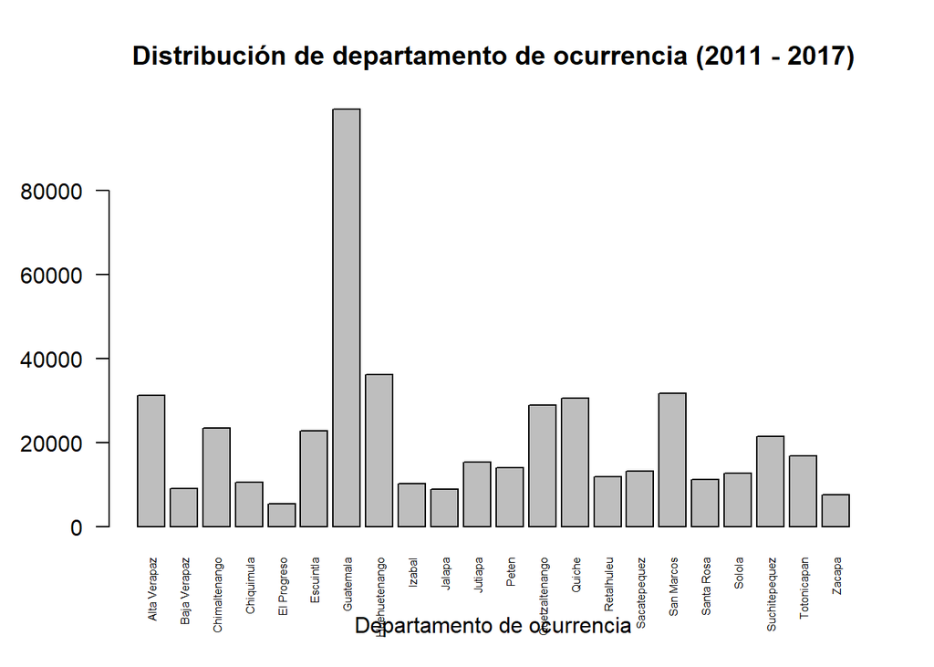

### Tabla de frecuencias para el municipio de ocurrencia

```
##
##                   Guatemala       Santa Catarina Pinula
##                       41743                        2148
##             San José Pinula          San José del Golfo
##                        2784                         661
##                    Palencia                   Chinautla
##                        1838                        2748
##           San Pedro Ayampuc                       Mixco
##                        1570                       11594
##      San Pedro Sacatepéquez       San Juan Sacatepéquez
##                        5011                        6646
##                San Raymundo                 Chuarrancho
##                        1269                         586
##                   Fraijanes                   Amatitlán
##                        1414                        4243
##                 Villa Nueva               Villa Canales
##                       10305                        4580
##                      Petapa                  Guastatoya
##                        3251                        1086
##                     Morazán   San Agustín Acasaguastlán
##                         371                        1076
## San Cristóbal Acasaguastlán                   El Jícaro
##                         183                         399
##                     Sansare                    Sanarate
##                         390                        1383
##          San Antonio la Paz           Antigua Guatemala
##                         504                        2633
##                 Jocotenango                    Pastores
##                         621                         516
##                    Sumpango       Santo Domingo Xenacoj
##                        1398                         330
##       Santiago Sacatepéquez  San Bartolomé Milpas Altas
##                        1250                         255
##      San Lucas Sacatepéquez    Santa Lucía Milpas Altas
##                        1135                         753
##      Magdalena Milpas Altas        Santa María de Jesús
##                         393                         766
##                Ciudad Vieja           San Miguel Dueñas
##                        1210                         423
##                  Alotenango San Antonio Aguas Calientes
```

[output cut: 294 more lines]

```
##                         176                          90
##                        01-1                        08-1
##                           5                           1
##                        09-1                        12-1
##                           1                           2
##                    Sipacate         San José la Maquina
##                           6                         328
##                     Petatán                        03-1
##                          29                           1
##                        05-1                        06-1
##                           1                           1
##                        07-1                        0928
##                           1                           2
##                        11-1                        13-1
##                           1                           1
```

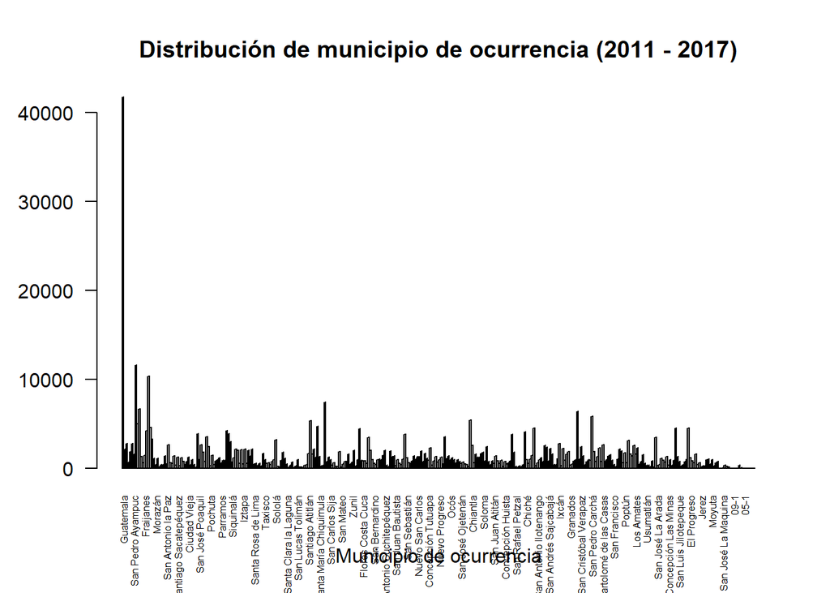

De la misma manera, es Guatemala el municipio que cuenta con la mayor cantidad de matrimonios.

### Tabla de frecuencias para la escolaridad del hombre

Donde: 1: ninguno 2: primaria 3: basica 4: diversificado 5: universitario 6: post grado 7: doctorado 9: ignorado

```
##
##             1             2             3             4             5
##         74886        160949         71764         73872         19522
##             6             8 Diversificado
##         31006           135         39441
```

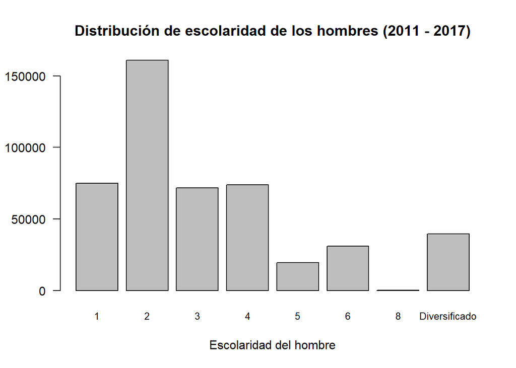

### Tabla de frecuencias para la escolaridad de la Mujer

1: ninguno 2: primaria 3: basica 4: diversificado 5: universitario 6: post grado 7: doctorado 9: ignorado

```
##
##             1             2             3             4             5
##        111542        133510         56918         71067         16419
##             6             8 Diversificado
##         44861            93         37165
```

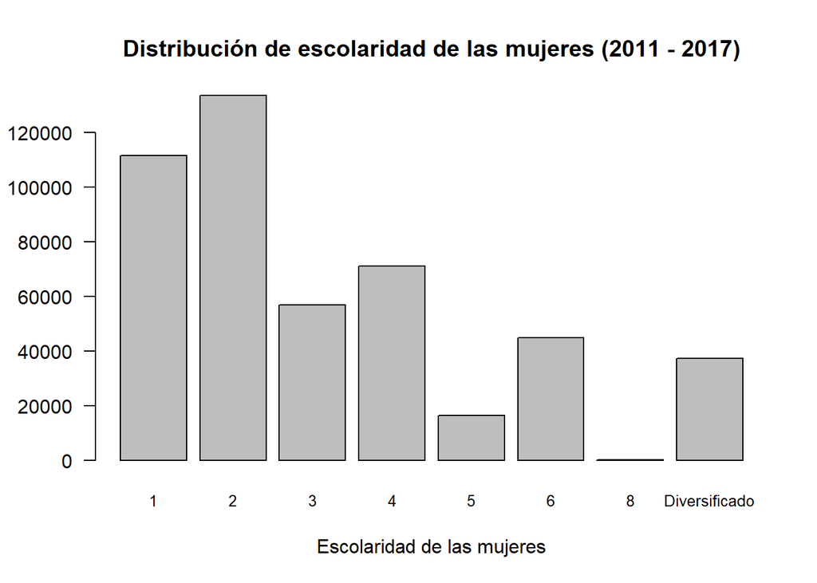

### Tabla de frecuencias para el grupo étnico del hombre

```
##
##         Garífuna         Ignorado         Indigena             Maya
##              107            46265            57528           112766
## Mestizo / Ladino      No indigena             Otro            Xinka
##           175347            76827             2654               81
```

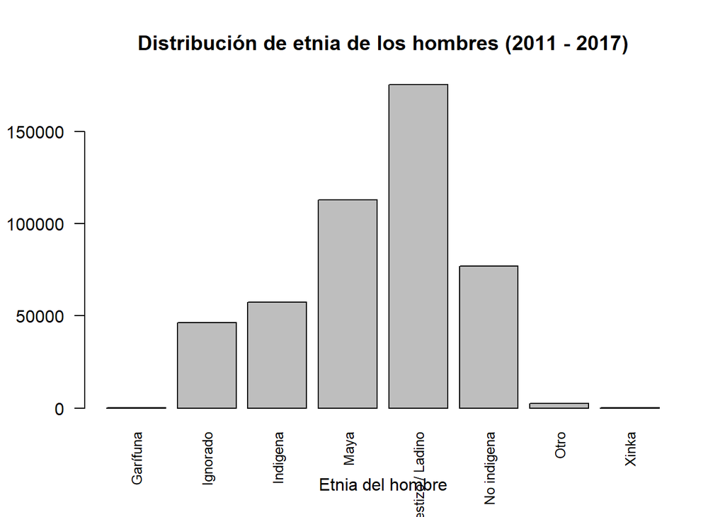

### Tabla de frecuencias para el grupo étnico de la mujer

```
##
##         Garífuna         Ignorado         Indigena             Maya
##               88            65747            55068           106378
## Mestizo / Ladino      No indigena             Otro            Xinka
##           167560            73720             2932               82
```

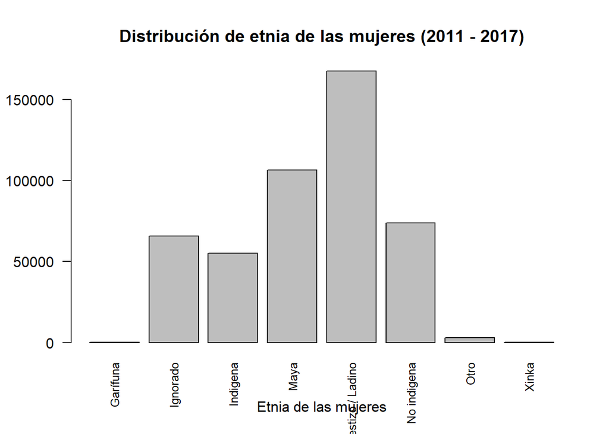

## Correlacion entre edades de los cónyuges

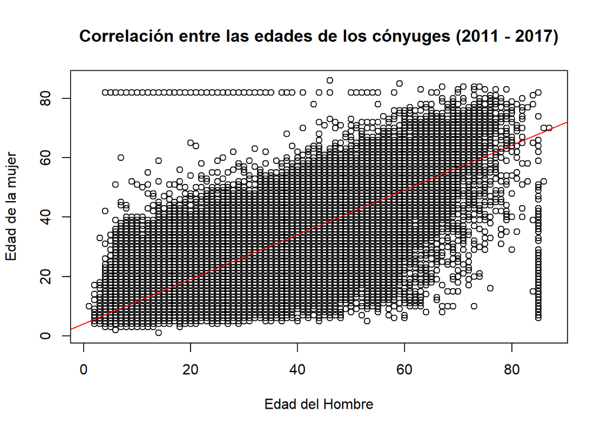

Como se puede ver, existen muchos datos extraños dentro del data set, estudiándolo se ha encontrado una gran cantidad de 1’s y otros datos en donde la edad de los “cónyuges” es incluso menor a 5 años, por lo que la presencia de estos datos nos ha llevado a buscar la naturaleza de las variables, por lo que revisando la lista de variables del INE de cada año, pudimos darnos cuenta que la edad más pequeña para mujeres durante los años fue 12 y de los hombres 14, por lo tanto se hizo un nuevo dataset para estudiar con precisión lo que deseamos estudiar. Se ha filtrado de la base de datos de matrimonios los valores en donde la edad de la mujer era menor a 18 (por el objetivo) y mayor a 12 años (para eliminar los datos no significativos o no lógicos), asimismo se filtró los datos en donde el hombre es menor a 14 años (de igual manera para eliminar esos datos confusos).

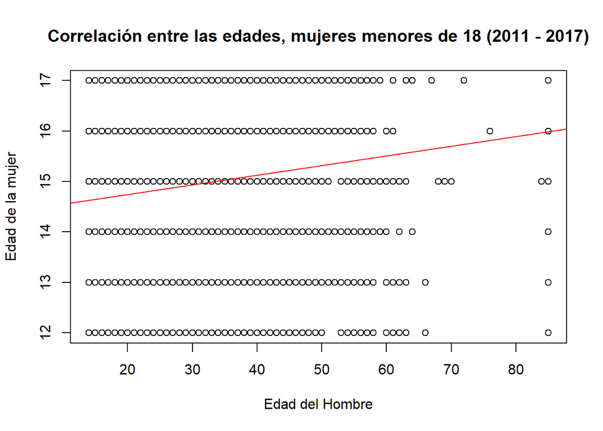

Filtrando los datos en donde las mujeres son menores a 18 años, es posible observar que una gran cantidad de mujeres se encuentran comprometidas con hombres mucho mayores a ellas, existen datos atípicos muy extensos y preocupantes, cabe mencionar que los datos que se encuentran en el fondo (muy pocos pero si existen) se encuentran así debido a que los datos no son indicados en el diagrama.

## Departamentos en donde se llevan a cabo los matrimonios de mujeres menores de edad

```
##
##   Alta Verapaz   Baja Verapaz  Chimaltenango     Chiquimula    El Progreso
##           1983            453           1146            745            421
##      Escuintla      Guatemala  Huehuetenango         Izabal         Jalapa
##           1420           6475           1955            797            672
##        Jutiapa          Peten Quetzaltenango         Quiche     Retalhuleu
##           1259           1115           1403           1442            581
##   Sacatepequez     San Marcos     Santa Rosa         Solola  Suchitepequez
##            751           1634            812            667            932
##    Totonicapan         Zacapa
##            732            613
```

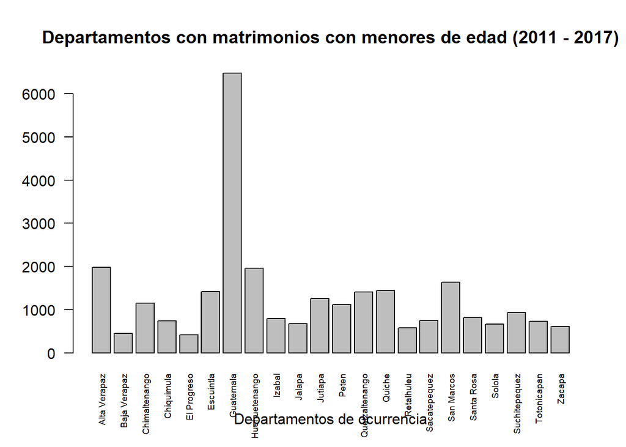

Puede observarse que muchos de estos matrimonios se llevan a cabo en el departamento de Guatemala, donde una gran población son ladinos.

## Municipios en donde se llevan a cabo los matrimonios de mujeres menores de edad

```
## depMun
##                   Guatemala       Santa Catarina Pinula
##                        2995                         166
##             San José Pinula          San José del Golfo
##                         167                          43
##                    Palencia                   Chinautla
##                         112                         168
##           San Pedro Ayampuc                       Mixco
##                          83                         817
##      San Pedro Sacatepéquez       San Juan Sacatepéquez
##                         270                         357
##                San Raymundo                 Chuarrancho
##                          65                          29
##                   Fraijanes                   Amatitlán
##                          86                         252
##                 Villa Nueva               Villa Canales
##                         576                         249
##                      Petapa                  Guastatoya
##                         205                          84
##                     Morazán   San Agustín Acasaguastlán
##                          31                          74
## San Cristóbal Acasaguastlán                   El Jícaro
##                          21                          23
##                     Sansare                    Sanarate
##                          37                         110
##          San Antonio la Paz           Antigua Guatemala
##                          41                         185
##                 Jocotenango                    Pastores
##                          49                          24
##                    Sumpango       Santo Domingo Xenacoj
##                          64                          28
##       Santiago Sacatepéquez  San Bartolomé Milpas Altas
##                          64                           7
##      San Lucas Sacatepéquez    Santa Lucía Milpas Altas
##                          88                          58
##      Magdalena Milpas Altas        Santa María de Jesús
##                          18                          25
##                Ciudad Vieja           San Miguel Dueñas
##                          52                          21
##                  Alotenango San Antonio Aguas Calientes
```

[output cut: 294 more lines]

```
##                          20                           4
##                        01-1                        08-1
##                           0                           1
##                        09-1                        12-1
##                           0                           0
##                    Sipacate         San José la Maquina
##                           0                          25
##                     Petatán                        03-1
##                           2                           0
##                        05-1                        06-1
##                           0                           0
##                        07-1                        0928
##                           0                           0
##                        11-1                        13-1
##                           0                           0
```

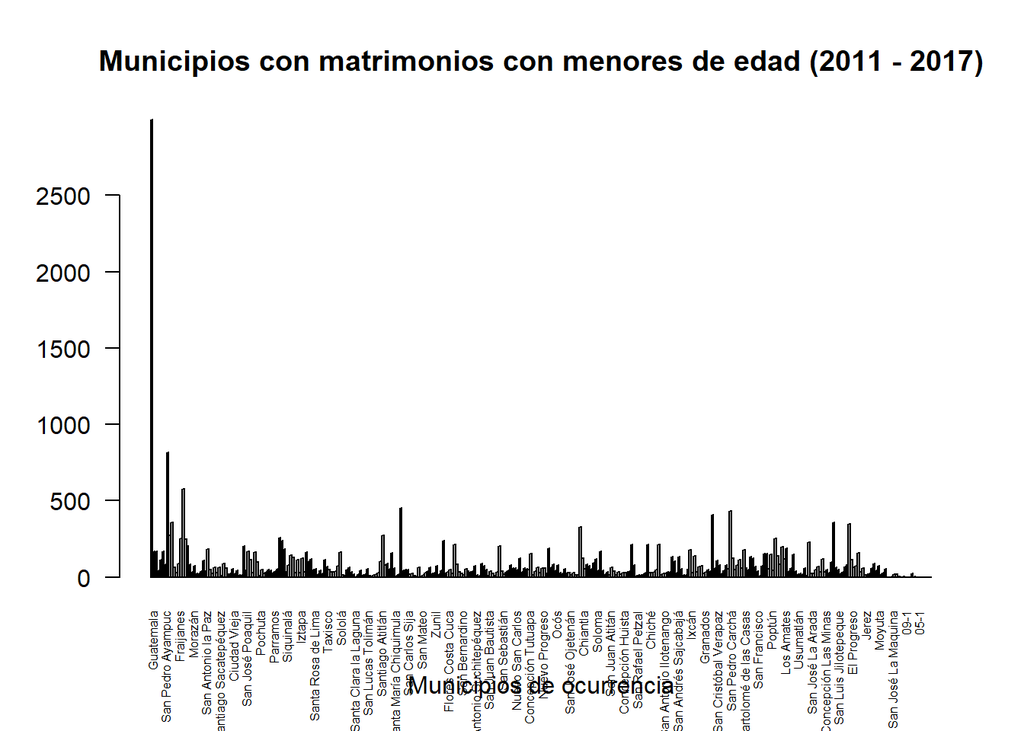

De la misma manera, puede observarse que la mayor cantidad de ocurrencias se encuentra en Guatemala.

## La etnia de la mujer en donde es más común este evento

```
## etniaMujer
##         Garífuna         Ignorado         Indigena             Maya
##               10             2636             2690             5924
## Mestizo / Ladino      No indigena             Otro            Xinka
##            11745             4900              100                3
```

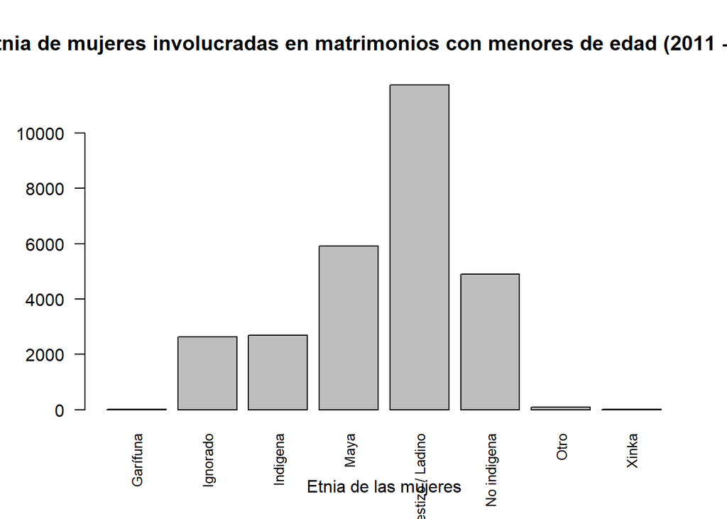

## La etnia del hombre en donde es más común este evento

```
## etniaHombre
##         Garífuna         Ignorado         Indigena             Maya
##                7             2721             2668             5893
## Mestizo / Ladino      No indigena             Otro            Xinka
##            11806             4762              143                8
```

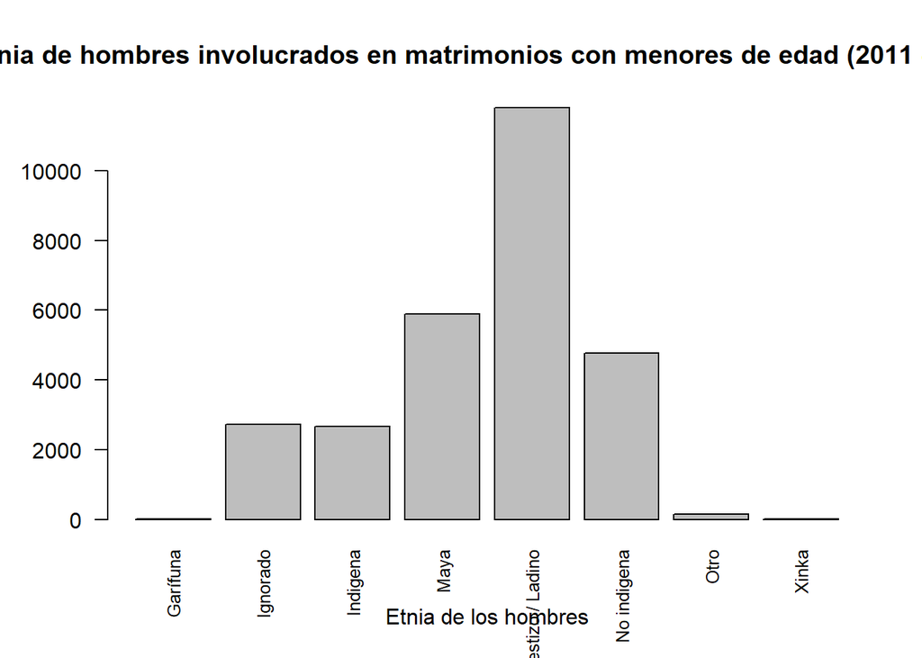

## Escolaridad del hombre involucrado en este evento

Donde: 1: ninguno 2: primaria 3: basica 4: diversificado 5: universitario 6: post grado 7: doctorado 9: ignorado

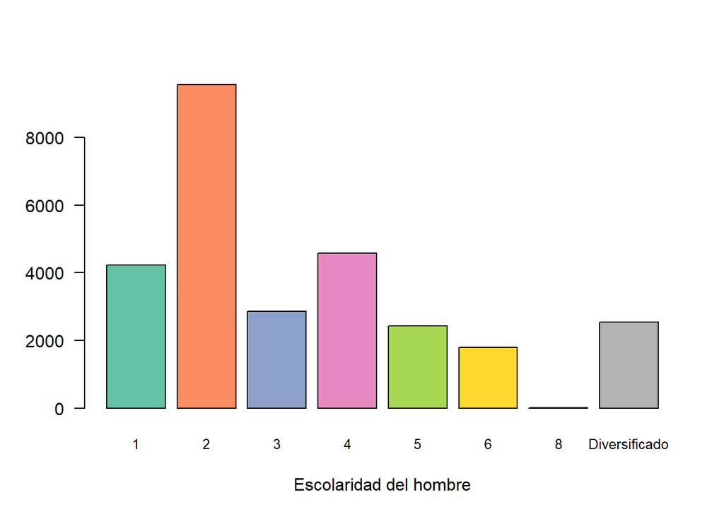

## Escolaridad de la mujer involucrada en este evento

Donde: 1: ninguno 2: primaria 3: basica 4: diversificado 5: universitario 6: post grado 7: doctorado 9: ignorado

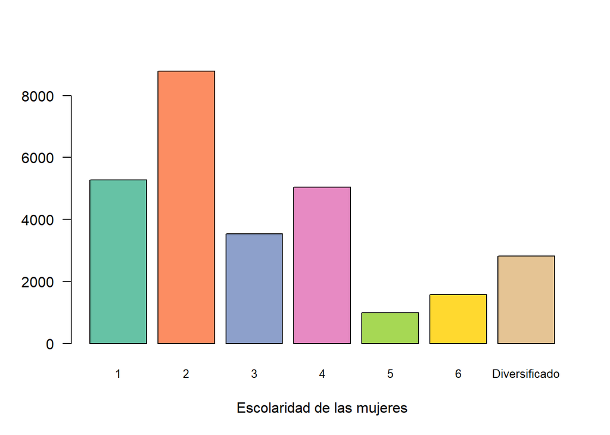

## Ocurrencia de matrimonios con menores de edad desde 2011 a 2017

[figure not shown]

```r
library(haven)
library(foreign)

set.seed(123)

nacimientos2011 <- read_sav("./SAVS/2011N.sav")
nacimientos2012 <- read_sav("./SAVS/2012Nacimientos.sav")
nacimientos2013 <- read_sav("./SAVS/2013N.sav")
nacimientos2014 <- read_sav("./SAVS/2014N.sav")
nacimientos2015 <- read_sav("./SAVS/2015N.sav")
nacimientos2016 <- read_sav("./SAVS/2016N.sav")
nacimientos2017 <- read_sav("./SAVS/2017N.sav")
nacimientos2018 <- read_sav("./SAVS/2018N.sav")
nacimientos2019 <- read_sav("./SAVS/2019N.sav")
```

#Histograma nacimientos 2011

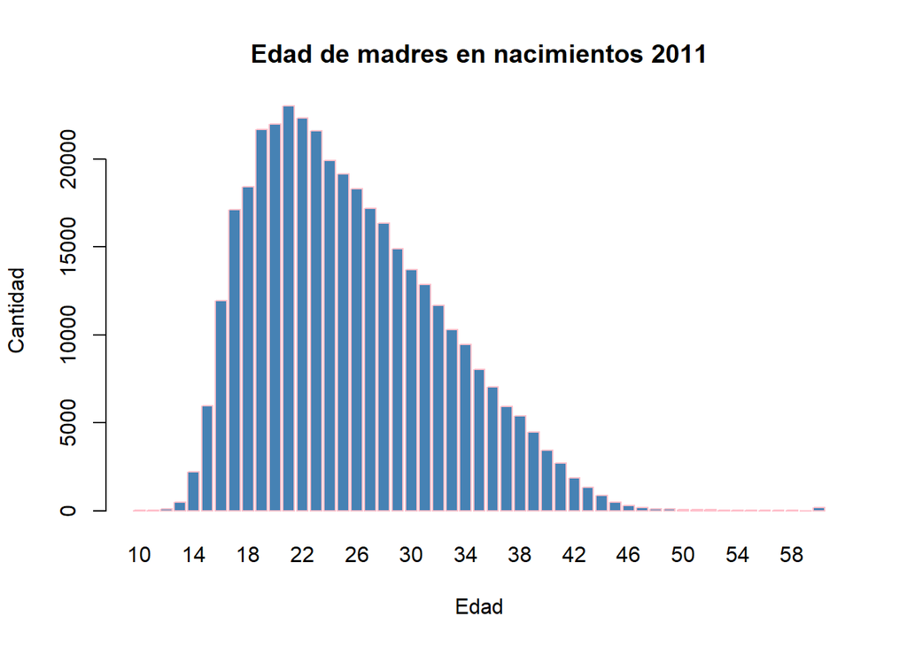

```r
library(dplyr)
library(ggplot2)
barplot(table(nacimientos2011$Edadm), main = "Edad de madres en nacimientos 2011", xlab = "Edad", ylab = "Cantidad", col = "steelblue" , border = "pink")
```

#Histograma nacimientos 2012

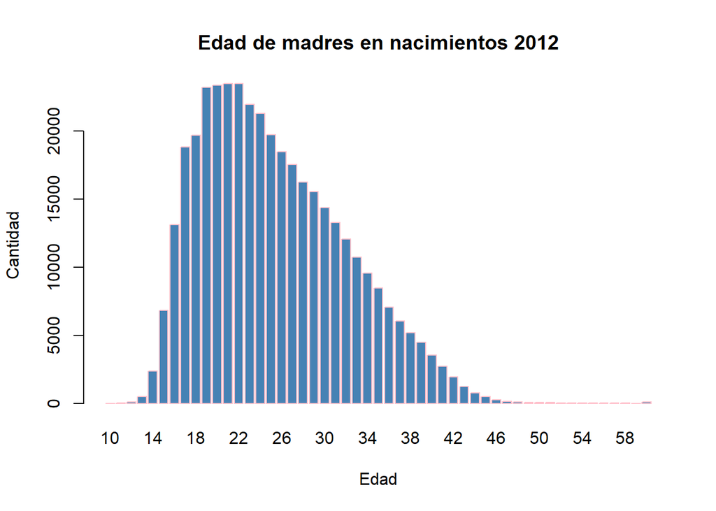

```r
library(dplyr)
library(ggplot2)
barplot(table(nacimientos2012$Edadm), main = "Edad de madres en nacimientos 2012", xlab = "Edad", ylab = "Cantidad", col = "steelblue" , border = "pink")
```

#Histograma nacimientos 2013

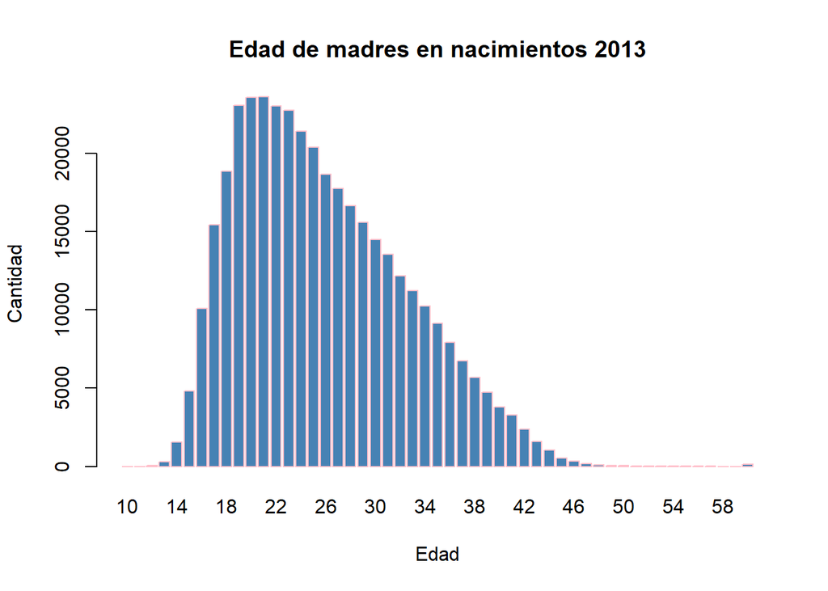

```r
library(dplyr)
library(ggplot2)
barplot(table(nacimientos2013$Edadm), main = "Edad de madres en nacimientos 2013", xlab = "Edad", ylab = "Cantidad", col = "steelblue" , border = "pink")
```

#Histograma nacimientos 2014

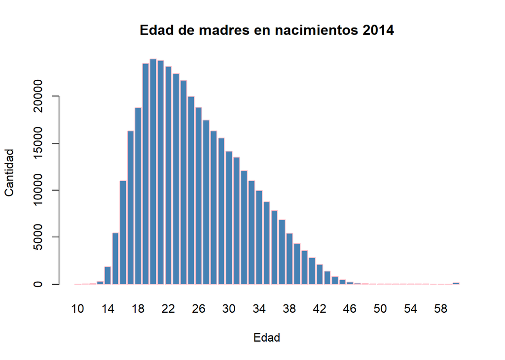

```r
library(dplyr)
library(ggplot2)
barplot(table(nacimientos2014$Edadm), main = "Edad de madres en nacimientos 2014", xlab = "Edad", ylab = "Cantidad", col = "steelblue" , border = "pink")
```

#Histograma nacimientos 2015

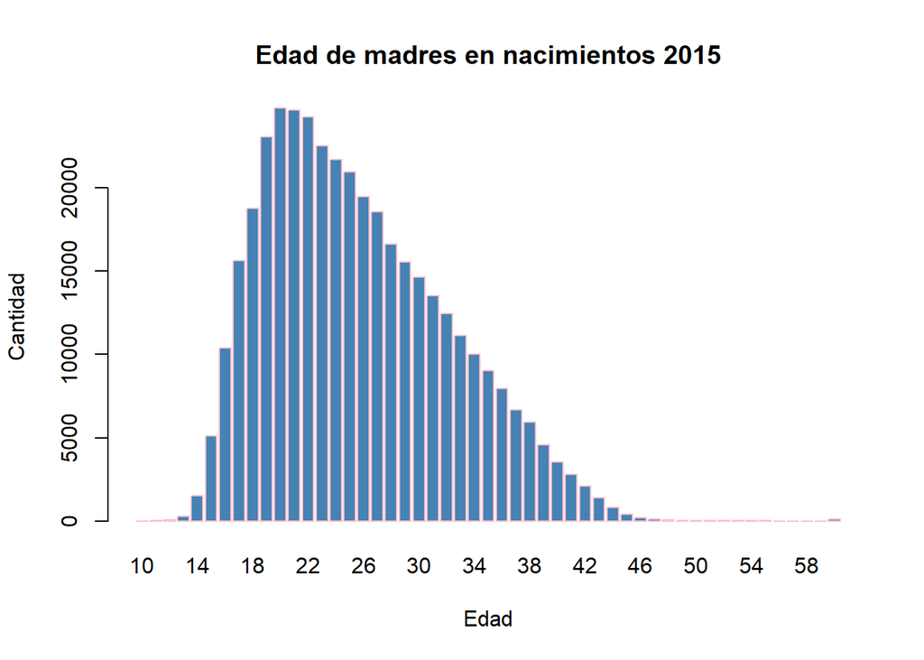

```r
library(dplyr)
library(ggplot2)
barplot(table(nacimientos2015$Edadm), main = "Edad de madres en nacimientos 2015", xlab = "Edad", ylab = "Cantidad", col = "steelblue" , border = "pink")
```

#Histograma nacimientos 2016

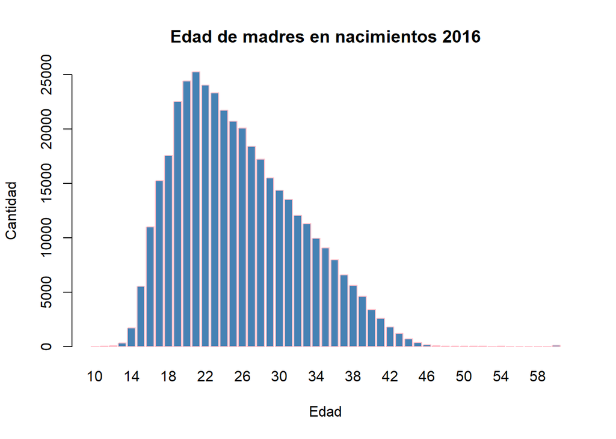

```r
library(dplyr)
library(ggplot2)
barplot(table(nacimientos2016$Edadm), main = "Edad de madres en nacimientos 2016", xlab = "Edad", ylab = "Cantidad", col = "steelblue" , border = "pink")
```

#Histograma nacimientos 2017

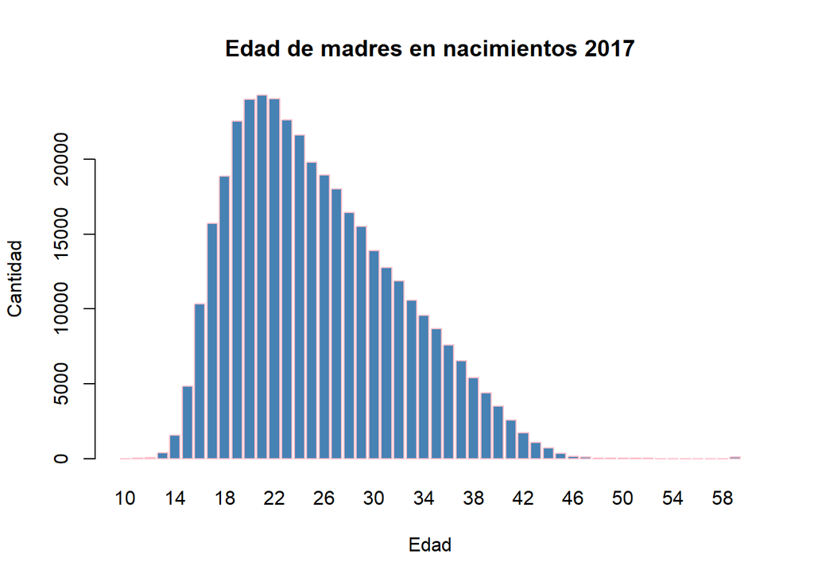

```r
library(dplyr)
library(ggplot2)
barplot(table(nacimientos2017$Edadm), main = "Edad de madres en nacimientos 2017", xlab = "Edad", ylab = "Cantidad", col = "steelblue" , border = "pink")
```

#Histograma nacimientos 2018

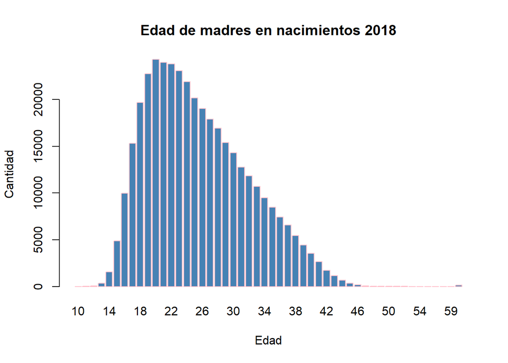

```r
library(dplyr)
library(ggplot2)
barplot(table(nacimientos2018$Edadm), main = "Edad de madres en nacimientos 2018", xlab = "Edad", ylab = "Cantidad", col = "steelblue" , border = "pink")
```

#Histograma nacimientos 2019

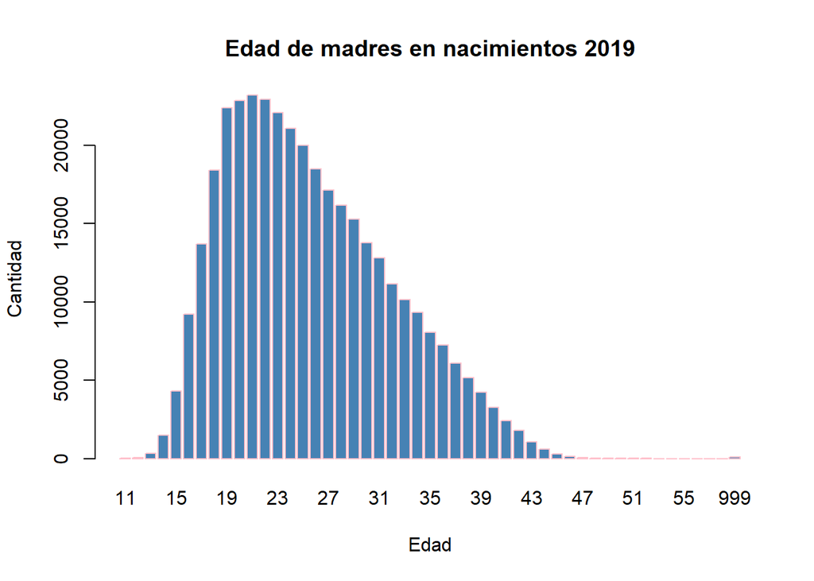

```r
library(dplyr)
library(ggplot2)
barplot(table(nacimientos2019$Edadm), main = "Edad de madres en nacimientos 2019", xlab = "Edad", ylab = "Cantidad", col = "steelblue" , border = "pink")
```

```r
library(haven)
library(dplyr)
X20111 <- read_sav("SAVS/20111.sav")

X20122 <- read_sav("SAVS/20122.sav")

X2013 <- read_sav("SAVS/2013M.sav")

X2014 <- read_sav("SAVS/2014M.sav")

X2015 <- read_sav("SAVS/2015M.sav")

X2016 <- read_sav("SAVS/2016M.sav")

X2017 <- read_sav("SAVS/2017M.sav")

X2018 <- read_sav("SAVS/2018M.sav")

X2019 <- read_sav("SAVS/2017M.sav")

datos2011 <- sum(X20111$Edadmuj < 18)

datos2012 <- sum(X20122$EDADMUJ < 18)

datos2013 <- sum(X2013$EDADMUJ < 18)

datos2014 <- sum(X2014$EDADMUJ < 18)

datos2015 <- sum(X2015$EDADMUJ < 18)

datos2016 <- sum(X2016$EDADMUJ < 18)

datos2017 <- sum(X2017$EDADMUJ < 18)

datos2018 <- sum(X2018$EDADMUJ < 18)

datos2019 <- sum(X2019$EDADMUJ < 18)

library(ggplot2)
df <- data.frame (año  = c("2011", "2012", "2013", "2014", "2015", "2016", "2017", "2018", "2019"),
                  matrimonios = c(datos2011, datos2012, datos2013, datos2014, datos2015, datos2016, datos2017, datos2018, datos2019)
                  )
print(df)
```

```
##    año matrimonios
## 1 2011       11795
## 2 2012       11913
## 3 2013       10956
## 4 2014       10127
## 5 2015        9697
## 6 2016          65
## 7 2017          22
## 8 2018           0
## 9 2019          22
```

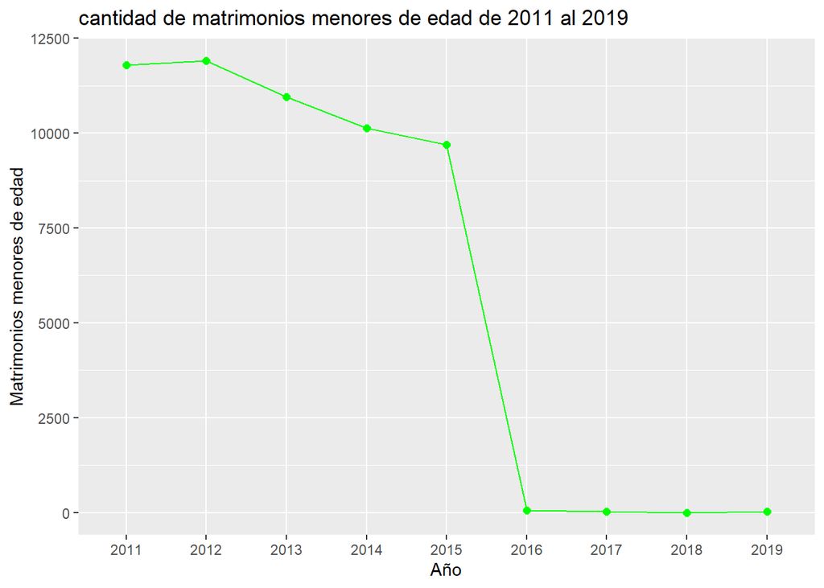

```r
ggplot(df, aes(x=año, y=matrimonios, group = 1)) +
  geom_point(size = 2, color = "green") +
  geom_line(color="green") +
  labs(x = "Año", y = "Matrimonios menores de edad", title = "cantidad de matrimonios menores de edad de 2011 al 2019")
```

# ———————————–Clustering——————————–

```
##      AÑOREG        EDADHOM         EDADMUJ          AÑOOCU
##  Min.   :2011   Min.   :14.00   Min.   :12.00   Min.   :1.000
##  1st Qu.:2012   1st Qu.:15.00   1st Qu.:13.00   1st Qu.:2.000
##  Median :2014   Median :17.00   Median :15.00   Median :4.000
##  Mean   :2014   Mean   :18.09   Mean   :14.71   Mean   :3.018
##  3rd Qu.:2015   3rd Qu.:19.00   3rd Qu.:16.00   3rd Qu.:4.000
##  Max.   :2017   Max.   :85.00   Max.   :17.00   Max.   :4.000
```

Se trabajará con las siguientes variables que tienen formato int para formas grupos: AÑOREG, ALOOCU, EDADHOM,EDADMUJ. Esto debido a que son variables que se pueden clasificar por grupos y los resultados pueden ser interpretados.

Para saber la mejor cantidad de clusters a utilizar, se hará lo siguiente:

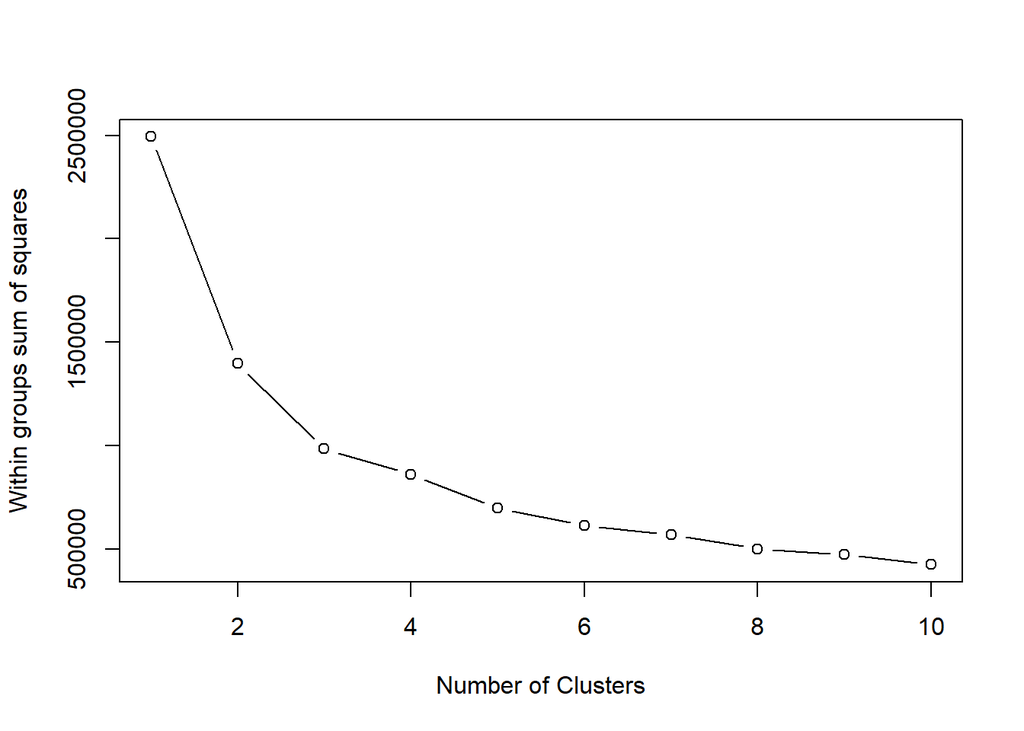

## Agrupamiento por medio de k-means

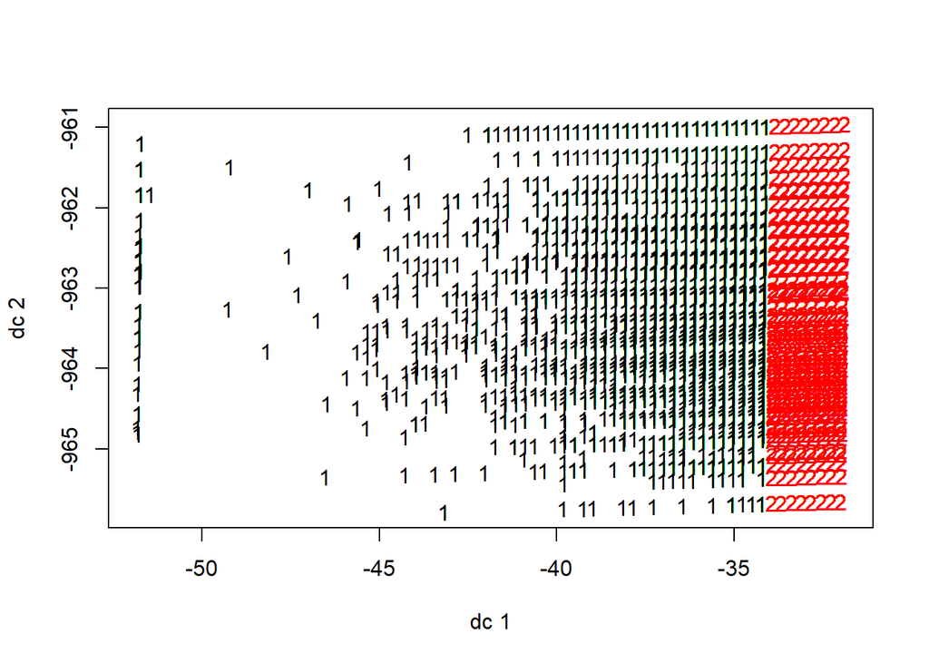

Se puede observar cómo los datos se encuentran divididos en 2 grupos, todos bastante concentrados a excepcion de algunos datos atipicos del grupo mas alejado, estos son alrededor de 40 matrimonios donde los hombres eran de edades de 80 - 60 con niñas menores de edad.

## Mixture of gaussians

```
## Package 'mclust' version 5.4.9
```

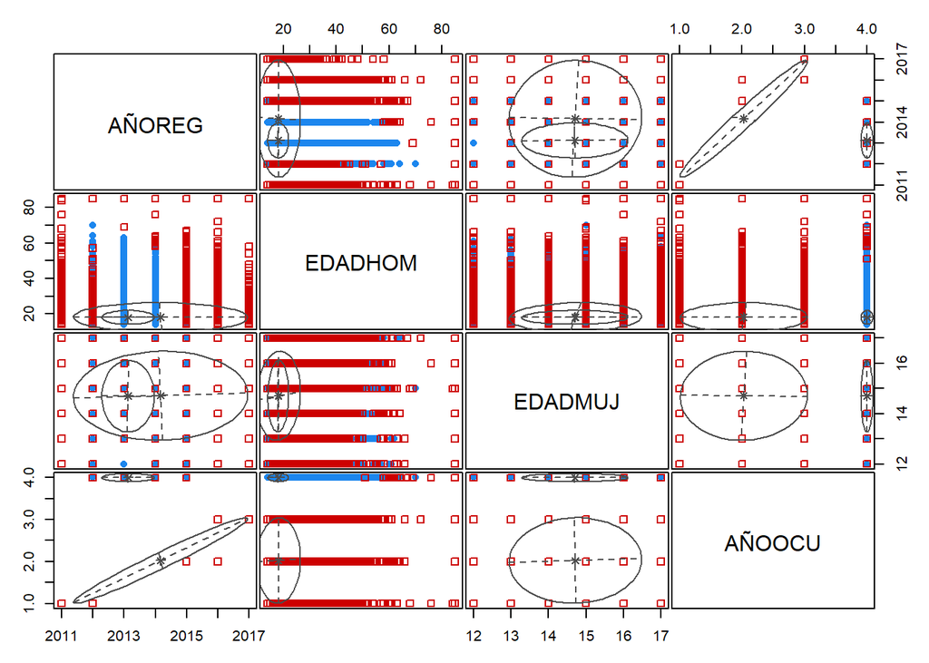

## Fuzzy C-means

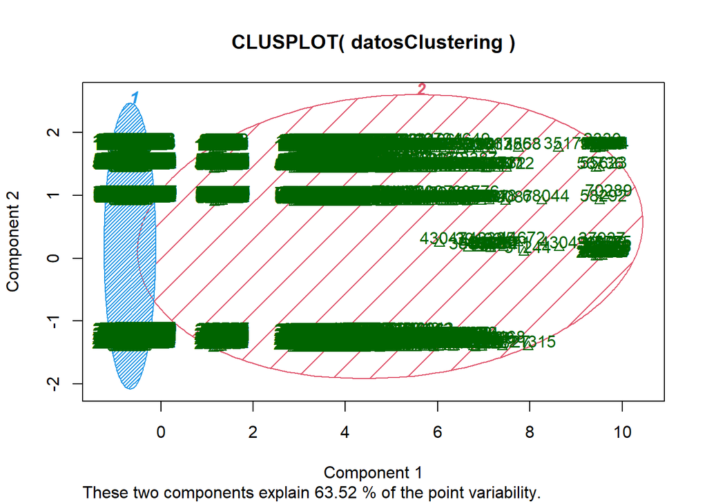

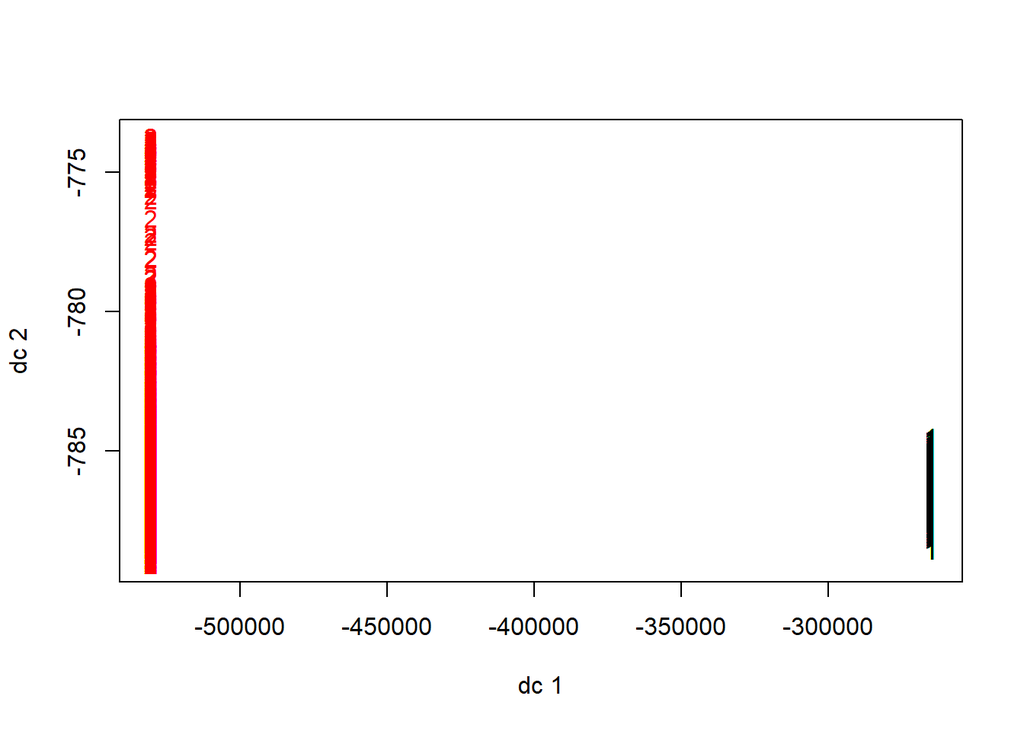

En el primer gráfico, clusplot, se puede ver detrás las regiones y como se encuentran los datos, además se indica que se explica casi 64% del punto de variabilidad.

En el segundo gráfico se encuentran ya separados los clusters y es posible observar la variabilidad entre ellos.

```
##      AÑOREG        EDADHOM         EDADMUJ          AÑOOCU          grupo
##  Min.   :2011   Min.   :22.00   Min.   :12.00   Min.   :1.000   Min.   :1
##  1st Qu.:2012   1st Qu.:23.00   1st Qu.:13.00   1st Qu.:2.000   1st Qu.:1
##  Median :2014   Median :25.00   Median :15.00   Median :4.000   Median :1
##  Mean   :2014   Mean   :27.28   Mean   :14.87   Mean   :3.031   Mean   :1
##  3rd Qu.:2015   3rd Qu.:29.00   3rd Qu.:16.00   3rd Qu.:4.000   3rd Qu.:1
##  Max.   :2017   Max.   :85.00   Max.   :17.00   Max.   :4.000   Max.   :1
```

```
##      AÑOREG        EDADHOM         EDADMUJ          AÑOOCU          grupo
##  Min.   :2011   Min.   :14.00   Min.   :12.00   Min.   :1.000   Min.   :2
##  1st Qu.:2012   1st Qu.:15.00   1st Qu.:13.00   1st Qu.:2.000   1st Qu.:2
##  Median :2014   Median :16.00   Median :15.00   Median :4.000   Median :2
##  Mean   :2014   Mean   :16.39   Mean   :14.68   Mean   :3.015   Mean   :2
##  3rd Qu.:2015   3rd Qu.:18.00   3rd Qu.:16.00   3rd Qu.:4.000   3rd Qu.:2
##  Max.   :2017   Max.   :21.00   Max.   :17.00   Max.   :4.000   Max.   :2
```

```
##      AÑOREG        EDADHOM         EDADMUJ         AÑOOCU      grupo
##  Min.   :2012   Min.   :14.00   Min.   :12.0   Min.   :4   Min.   :1.000
##  1st Qu.:2012   1st Qu.:15.00   1st Qu.:13.0   1st Qu.:4   1st Qu.:2.000
##  Median :2013   Median :17.00   Median :15.0   Median :4   Median :2.000
##  Mean   :2013   Mean   :18.03   Mean   :14.7   Mean   :4   Mean   :1.845
##  3rd Qu.:2014   3rd Qu.:19.00   3rd Qu.:16.0   3rd Qu.:4   3rd Qu.:2.000
##  Max.   :2015   Max.   :70.00   Max.   :17.0   Max.   :4   Max.   :2.000
##      mxGau
##  Min.   :1
##  1st Qu.:1
##  Median :1
##  Mean   :1
##  3rd Qu.:1
##  Max.   :1
```

```
##      AÑOREG        EDADHOM         EDADMUJ          AÑOOCU          grupo
##  Min.   :2011   Min.   :14.00   Min.   :12.00   Min.   :1.000   Min.   :1.000
##  1st Qu.:2011   1st Qu.:15.00   1st Qu.:13.00   1st Qu.:1.000   1st Qu.:2.000
##  Median :2015   Median :17.00   Median :15.00   Median :2.000   Median :2.000
##  Mean   :2014   Mean   :18.14   Mean   :14.71   Mean   :2.026   Mean   :1.844
##  3rd Qu.:2016   3rd Qu.:19.00   3rd Qu.:16.00   3rd Qu.:3.000   3rd Qu.:2.000
##  Max.   :2017   Max.   :85.00   Max.   :17.00   Max.   :4.000   Max.   :2.000
##      mxGau
##  Min.   :2
##  1st Qu.:2
##  Median :2
##  Mean   :2
##  3rd Qu.:2
##  Max.   :2
```

```
##      AÑOREG        EDADHOM         EDADMUJ          AÑOOCU          grupo
##  Min.   :2011   Min.   :14.00   Min.   :12.00   Min.   :1.000   Min.   :2
##  1st Qu.:2012   1st Qu.:15.00   1st Qu.:13.00   1st Qu.:2.000   1st Qu.:2
##  Median :2014   Median :16.00   Median :15.00   Median :4.000   Median :2
##  Mean   :2014   Mean   :16.16   Mean   :14.67   Mean   :3.015   Mean   :2
##  3rd Qu.:2015   3rd Qu.:18.00   3rd Qu.:16.00   3rd Qu.:4.000   3rd Qu.:2
##  Max.   :2017   Max.   :20.00   Max.   :17.00   Max.   :4.000   Max.   :2
##      mxGau          FCGrupos
##  Min.   :1.000   Min.   :1
##  1st Qu.:1.000   1st Qu.:1
##  Median :1.000   Median :1
##  Mean   :1.498   Mean   :1
##  3rd Qu.:2.000   3rd Qu.:1
##  Max.   :2.000   Max.   :1
```

```
##      AÑOREG        EDADHOM      EDADMUJ          AÑOOCU          grupo
##  Min.   :2011   Min.   :21   Min.   :12.00   Min.   :1.000   Min.   :1.000
##  1st Qu.:2012   1st Qu.:22   1st Qu.:13.00   1st Qu.:2.000   1st Qu.:1.000
##  Median :2014   Median :24   Median :15.00   Median :4.000   Median :1.000
##  Mean   :2014   Mean   :26   Mean   :14.88   Mean   :3.028   Mean   :1.204
##  3rd Qu.:2015   3rd Qu.:27   3rd Qu.:16.00   3rd Qu.:4.000   3rd Qu.:1.000
##  Max.   :2017   Max.   :85   Max.   :17.00   Max.   :4.000   Max.   :2.000
##      mxGau          FCGrupos
##  Min.   :1.000   Min.   :2
##  1st Qu.:1.000   1st Qu.:2
##  Median :1.000   Median :2
##  Mean   :1.498   Mean   :2
##  3rd Qu.:2.000   3rd Qu.:2
##  Max.   :2.000   Max.   :2
```

En el resúmer por fuzzy se puede identificar que la media de la edad de las mujeres parece ser constante, los años un poco variados pero en cierta manera se observa una relación entre año y edad del hombre.

## Evaluación de la tendencia de agrupamiento:

En esté análisis de datos consiste en examinar si los datos son agrupables, es decir, si los datos contienen cualquier estructura de agrupación inherente. Esto debe comprobarse antes de aplicar el análisis de agrupación.

### En hombres

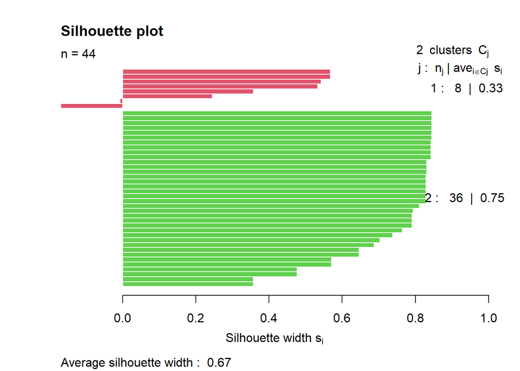

Nos podemos dar cuenta que para la silueta con dos clusters nos presenta un valor bastante alto por encima de .5, indicandonos la distribucion de grupos de forma optima, nuestra silueta para hombres presenta 0.67, utilizando dos clusters se interpretan de mejor forma a comparacion con 2 clusteres. ### En mujeres

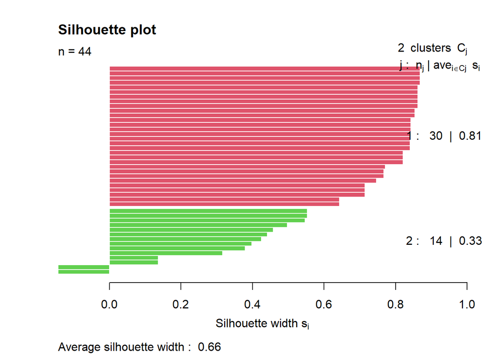

Similar que para el cluster de hombres, para mujeres tambien tenemos 0.66 u dato bastante alto, indicandonos tambien que utilizar dos clusters es la forma optima de interpretar nuestros conjuntos de datos

#—————————Apartado de predición———————————-

Con el fin de poder investigar más a fondo bajo que criterios es más probable que en un casamiento se encuentre implicada una mujer menor de edad (que en el análisis anterior se evidenció era más recurrente que los hombres) se decidió untilizar ML para poder predecir si dadas ciertas características una mujer será menor de edad en un matrimonio, para poder determinar en que lugares (o situaciones) debe ser atendido este problema.

Con el objetivo de poder estudiar por categorias, se realizará una variable de clasificación adicional en el dataframe para poder llevar a cabo la predicción, en este caso se separó por menores y mayores de edad

A su vez, es necesario convertir todos los datos a factores para poder hacer un análisis con RWEKA

Luego, hacemos los conjuntos de entrenamiento y prueba y se borran las bases de datos de cada año individuales para liberar espacio en la memoria de R

## Segundo análisis de datos

Debido a que al tratar de hacer las predicciones se ha contado con errores debido a la gran cantidad que se está manejando, se ha decidido verificar cuáles son las variables más significativas para trabajar únicamente con ellas, sin embargo, al contar con variables que no son únicamente numéricas no es posible realizar una correlación entre ellas, por lo que se ha estudiado los datos de cada variable y se ha discutido su importancia, llegando a lo siguiente:

En el caso de la ocupación, tanto de hombres como mujeres, se cuenta con demasiados valores diferentes por lo que no se considera que sea significativo. En el caso de los hombres se cuenta con 489 diferentes ocupaciones y en el caso de las mujeres se cuenta con 487 ocupaciones diferentes. El número de nupcias también es ignorado ya que los valores de “ignorado” y “none” representan en hombres el 37.0% y el 44.61% respectivamente y en mujeres representa el 37.06% y 44.61% respectivamente, por lo que no se vuelve tan significativo.

La variable de escolaridad tanto de hombres como mujeres también será eliminada ya que los valores de ignorado y ninguno representan un 13.35% y 21.89% para los hombres y un 13.06% y 30.68% para las mujeres. Por último, aquellos datos que tengan el registro, como el departamento de ocurrencia o el municipio de ocurrencia, también serán eliminados debido a que es más confiable trabajar con los datos de ocurrencia, porque en muchos casos se registran matrimonios tiempo después de que hayan ocurrido o incluso en lugares diferentes, por lo que los datos de registro no son tan confiables, además, en caso de que sí se haya registrado en la fecha y lugares correctos, se tendría los datos duplicados.

Por lo que nos quedamos con los valores de: Clase de unión, edad del hombre, etnia del hombre y de la mujer, nacionalidad del hombre y mujer, departamento, municipio, mes, año, día y área de ocurrencia y la variable a predecir que es si la mujer es mayor o menor de edad